# Correspondence Analysis

Dataset correspondance.matrix

This dataset contains 97 rows and 185 columns.

### 1. Study of the outliers

The detection of outliers does not apply to CA results.

### 2. Inertia distribution

The inertia of the first dimensions shows if there are strong relationships between variables and suggests the number of dimensions that should be studied.

The first two dimensions of analyse express **21.7%** of the total dataset inertia ; that means that 21.7% of the rows (or columns) cloud total variability is explained by the plane. This is a small percentage and the first plane just represents a part of the data variability. This value is greater than the reference value that equals **6.05%**, the variability explained by this plane is thus significant (the reference value is the 0.95-quantile of the inertia percentages distribution obtained by simulating 327 data tables of equivalent size on the basis of a uniform distribution).

From these observations, it is interesting to consider the next dimensions which also express a high percentage of the total inertia.

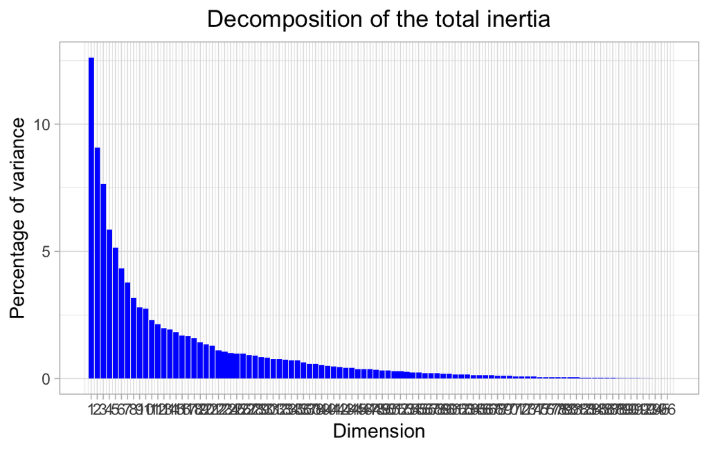

**Figure 2 - Decomposition of the total inertia**

An estimation of the right number of axis to interpret suggests to restrict the analysis to the description of the first 12 axis. These axis present an amount of inertia greater than those obtained by the 0.95-quantile of random distributions (61.6% against 30.22%). This observation suggests that only these axis are carrying a real information. As a consequence, the description will stand to these axis.

### 3. Description of the plane 1:2

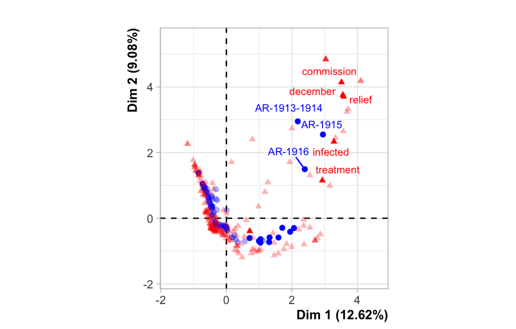

**Figure 3.1 - Overlayed factor map (CA)** *The labeled rows are those with the higher contribution to the plane construction.* *The labeled columns are those the best shown on the plane.*

The **dimension 1** opposes factors such as *AR-1915*, *AR-1916*, *AR-1913-1914*, *AR-1925*, *AR-1920*, *AR-1919*, *AR-1921*, *AR-1917*, *AR-1926* and *AR-1918* (to the right of the graph, characterized by a strongly positive coordinate on the axis) to factors such as *AR-2000* (to the left of the graph, characterized by a strongly negative coordinate on the axis).

The group in which the factors *AR-1925*, *AR-1920*, *AR-1919*, *AR-1921*, *AR-1917*, *AR-1926*, *AR-1918*, *AR-1922* and *AR-1924* stand (characterized by a positive coordinate on the axis) is sharing :

- high frequency for factors like *college*, *hookworm*, *school*, *medical*, *control*, *health*, *malaria*, *china*, *hospital* and *public* (factors are sorted from the most common).
- low frequency for the factors *program*, *development*, *center*, *support*, *study*, *costs*, *institute*, *project* and *university* (factors are sorted from the rarest).

The group in which the factors *AR-1915*, *AR-1916* and *AR-1913-1914* stand (characterized by a positive coordinate on the axis) is sharing :

- high frequency for factors like *committee*, *december*, *relief*, *commission*, *total*, *infected*, *examined*, *cured*, *persons* and *foundation* (factors are sorted from the most common).
- low frequency for the variable *university*.

The group in which the factor *AR-2000* stands (characterized by a negative coordinate on the axis) is sharing :

- high frequency for factors like *program*, *development*, *center*, *study*, *support*, *university*, *institute*, *costs*, *project* and *rice* (factors are sorted from the most common).
- low frequency for factors like *medical*, *china*, *school*, *hookworm*, *board*, *college*, *health*, *disease*, *control* and *public* (factors are sorted from the rarest).

The **dimension 2** opposes factors such as *AR-1915*, *AR-1916*, *AR-1913-1914* and *AR-2000* (to the top of the graph, characterized by a strongly positive coordinate on the axis) to factors such as *AR-1925*, *AR-1920*, *AR-1919*, *AR-1921*, *AR-1917*, *AR-1926*, *AR-1918*, *AR-1922* and *AR-1924* (to the bottom of the graph, characterized by a strongly negative coordinate on the axis).

The group in which the factor *AR-2000* stands (characterized by a positive coordinate on the axis) is sharing :

- high frequency for factors like *program*, *development*, *center*, *study*, *support*, *university*, *institute*, *costs*, *project* and *rice* (factors are sorted from the most common).
- low frequency for factors like *medical*, *china*, *school*, *hookworm*, *board*, *college*, *health*, *disease*, *control* and *public* (factors are sorted from the rarest).

The group in which the factors *AR-1915*, *AR-1916* and *AR-1913-1914* stand (characterized by a positive coordinate on the axis) is sharing :

- high frequency for factors like *committee*, *december*, *relief*, *commission*, *total*, *infected*, *examined*, *cured*, *persons* and *foundation* (factors are sorted from the most common).
- low frequency for the variable *university*.

The group in which the factors *AR-1925*, *AR-1920*, *AR-1919*, *AR-1921*, *AR-1917*, *AR-1926*, *AR-1918*, *AR-1922* and *AR-1924* stand (characterized by a negative coordinate on the axis) is sharing :

- high frequency for factors like *college*, *hookworm*, *school*, *medical*, *control*, *health*, *malaria*, *china*, *hospital* and *public* (factors are sorted from the most common).
- low frequency for the factors *program*, *development*, *center*, *support*, *study*, *costs*, *institute*, *project* and *university* (factors are sorted from the rarest).

### 4. Description of the plane 3:4

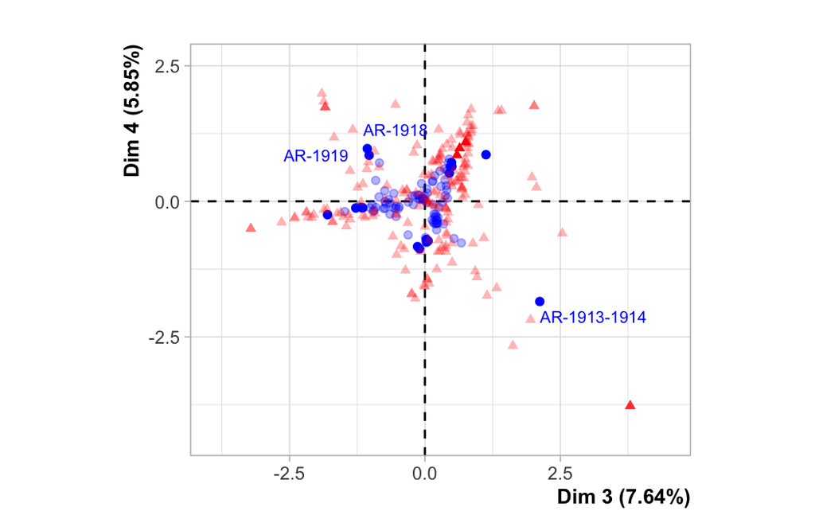

**Figure 4.1 - Overlayed factor map (CA)** *The labeled rows are those with the higher contribution to the plane construction.* *The labeled columns are those the best shown on the plane.*

The **dimension 3** opposes factors such as *AR-1958*, *AR-1959*, *AR-1960*, *AR-1913-1914*, *AR-1956*, *AR-1932*, *AR-1931*, *AR-1930* and *AR-1933* (to the right of the graph, characterized by a strongly positive coordinate on the axis) to factors such as *AR-2000*, *AR-2001*, *AR-2002*, *AR-1918*, *AR-1919* and *AR-1999* (to the left of the graph, characterized by a strongly negative coordinate on the axis).

The group in which the factors *AR-1958*, *AR-1959*, *AR-1960* and *AR-1956* stand (characterized by a positive coordinate on the axis) is sharing :

- high frequency for factors like *agriculture*, *usa*, *mexico*, *professor*, *study*, *faculty*, *plant*, *medicine*, *science* and *united* (factors are sorted from the most common).
- low frequency for the factors *health*, *ih*, *china*, *malaria*, *aid*, *project*, *fever* and *costs* (factors are sorted from the rarest).

The group in which the factors *AR-1932*, *AR-1931*, *AR-1930* and *AR-1933* stand (characterized by a positive coordinate on the axis) is sharing :

- high frequency for factors like *aid*, *ih*, *fellowships*, *division*, *public*, *council*, *health*, *social*, *city* and *administration* (factors are sorted from the most common).
- low frequency for factors like *center*, *professor*, *agricultural*, *support*, *development*, *agriculture*, *project*, *usa*, *costs* and *mexico* (factors are sorted from the rarest).

The group in which the factor *AR-1913-1914* stands (characterized by a positive coordinate on the axis) is sharing :

- high frequency for factors like *total*, *time*, *society*, *relief*, *meeting*, *john*, *income*, *government*, *field* and *december* (factors are sorted from the most common).

The group in which the factors *AR-2000*, *AR-2001*, *AR-2002*, *AR-1918*, *AR-1919* and *AR-1999* stand (characterized by a negative coordinate on the axis) is sharing :

- high frequency for factors like *project*, *costs*, *kenya*, *california*, *board*, *africa*, *exhibit*, *disease*, *infection* and *support* (factors are sorted from the most common).
- low frequency for factors like *studies*, *sciences*, *social*, *american*, *foundation*, *national*, *institute*, *school*, *university* and *medicine* (factors are sorted from the rarest).

The **dimension 4** opposes factors such as *AR-1958*, *AR-1959*, *AR-1960* and *AR-1956* (to the top of the graph, characterized by a strongly positive coordinate on the axis) to factors such as *AR-1913-1914*, *AR-1932*, *AR-1931*, *AR-1930* and *AR-1933* (to the bottom of the graph, characterized by a strongly negative coordinate on the axis).

The group in which the factors *AR-1958*, *AR-1959*, *AR-1960* and *AR-1956* stand (characterized by a positive coordinate on the axis) is sharing :

- high frequency for factors like *agriculture*, *usa*, *mexico*, *professor*, *study*, *faculty*, *plant*, *medicine*, *science* and *united* (factors are sorted from the most common).
- low frequency for the factors *health*, *ih*, *china*, *malaria*, *aid*, *project*, *fever* and *costs* (factors are sorted from the rarest).

The group in which the factors *AR-1932*, *AR-1931*, *AR-1930* and *AR-1933* stand (characterized by a negative coordinate on the axis) is sharing :

- high frequency for factors like *aid*, *ih*, *fellowships*, *division*, *public*, *council*, *health*, *social*, *city* and *administration* (factors are sorted from the most common).
- low frequency for factors like *center*, *professor*, *agricultural*, *support*, *development*, *agriculture*, *project*, *usa*, *costs* and *mexico* (factors are sorted from the rarest).

The group in which the factor *AR-1913-1914* stands (characterized by a negative coordinate on the axis) is sharing :

- high frequency for factors like *total*, *time*, *society*, *relief*, *meeting*, *john*, *income*, *government*, *field* and *december* (factors are sorted from the most common).

### 5. Description of the plane 5:6

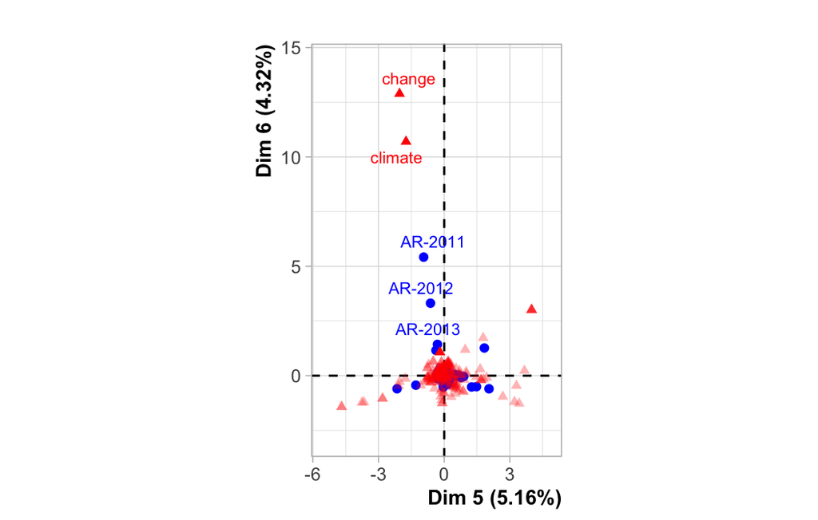

**Figure 5.1 - Overlayed factor map (CA)** *The labeled rows are those with the higher contribution to the plane construction.* *The labeled columns are those the best shown on the plane.*

The **dimension 5** opposes factors such as *AR-1972*, *AR-1973* and *AR-1974* (to the right of the graph, characterized by a strongly positive coordinate on the axis) to factors such as *AR-1915* and *AR-1916* (to the left of the graph, characterized by a strongly negative coordinate on the axis).

The group in which the factors *AR-1972*, *AR-1973* and *AR-1974* stand (characterized by a positive coordinate on the axis) is sharing :

- high frequency for factors like *university*, *institute*, *center*, *special*, *study*, *program*, *company*, *development*, *training* and *population* (factors are sorted from the most common).
- low frequency for the variable *health*.

The group in which the factors *AR-1915* and *AR-1916* stand (characterized by a negative coordinate on the axis) is sharing :

- high frequency for factors like *examined*, *war*, *sanitary*, *latrine*, *cured*, *china*, *persons*, *medical*, *treatment* and *board* (factors are sorted from the most common).

The **dimension 6** particularly distinguishes factors such as *AR-2011* (to the top of the graph, characterized by a strongly positive coordinate on the axis).

These factors form a group sharing : - high frequency for the factors *change*, *climate*, *costs* and *support* (factors are sorted from the most common).

### 6. Description of the plane 7:8

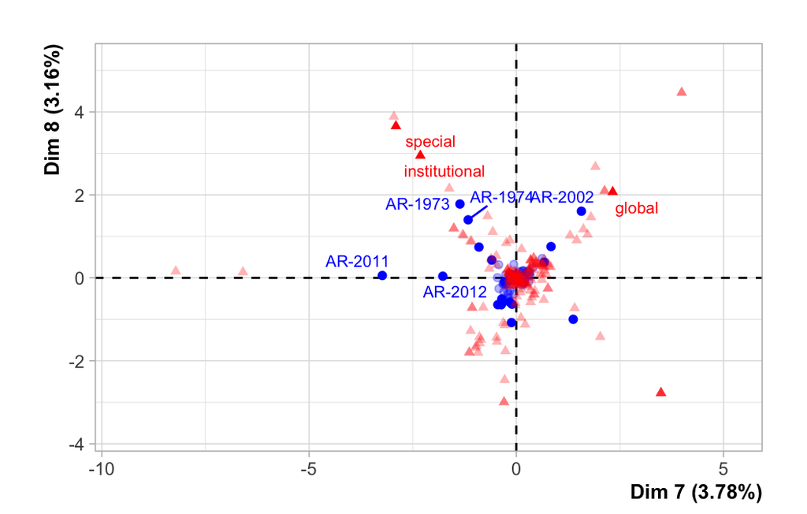

**Figure 6.1 - Overlayed factor map (CA)** *The labeled rows are those with the higher contribution to the plane construction.* *The labeled columns are those the best shown on the plane.*

The **dimension 7** opposes factors such as *AR-2002*, *AR-2000*, *AR-1913-1914*, *AR-2004* and *AR-1999* (to the right of the graph, characterized by a strongly positive coordinate on the axis) to factors such as *AR-2011* (to the left of the graph, characterized by a strongly negative coordinate on the axis).

The group in which the factors *AR-2000*, *AR-2004* and *AR-1999* stand (characterized by a positive coordinate on the axis) is sharing :

- high frequency for the factors *professor*, *kenya*, *global*, *africa*, *california* and *project* (factors are sorted from the most common).
- low frequency for the factors *national* and *sciences* (factors are sorted from the rarest).

The group in which the factor *AR-1913-1914* stands (characterized by a positive coordinate on the axis) is sharing :

- high frequency for factors like *time*, *john*, *infected*, *government*, *field*, *december*, *treatment*, *society*, *relief* and *meeting* (factors are sorted from the most common).
- low frequency for the factors *development* and *support* (factors are sorted from the rarest).

The group in which the factor *AR-2002* stands (characterized by a positive coordinate on the axis) is sharing :

- high frequency for the factors *conference*, *policy*, *held*, *washington* and *africa* (factors are sorted from the most common).
- low frequency for the variable *international*.

The group in which the factor *AR-2011* stands (characterized by a negative coordinate on the axis) is sharing :

- high frequency for the factors *change*, *climate* and *united* (factors are sorted from the most common).
- low frequency for the variable *international*.

The **dimension 8** opposes factors such as *AR-1974*, *AR-1973* and *AR-2002* (to the top of the graph, characterized by a strongly positive coordinate on the axis) to factors such as *AR-1967*, *AR-1968*, *AR-1966*, *AR-1994*, *AR-1993* and *AR-1992* (to the bottom of the graph, characterized by a strongly negative coordinate on the axis).

The group in which the factors *AR-1974* and *AR-1973* stand (characterized by a positive coordinate on the axis) is sharing :

- high frequency for the factors *grant*, *institutional*, *special*, *company*, *fellowships*, *environmental*, *continued* and *corporation* (factors are sorted from the most common).
- low frequency for the factors *support* and *health* (factors are sorted from the rarest).

The group in which the factor *AR-2002* stands (characterized by a positive coordinate on the axis) is sharing :

- high frequency for the factors *conference*, *policy*, *held*, *washington* and *africa* (factors are sorted from the most common).
- low frequency for the variable *international*.

The group in which the factors *AR-1967*, *AR-1968*, *AR-1966*, *AR-1994*, *AR-1993* and *AR-1992* stand (characterized by a negative coordinate on the axis) is sharing :

- high frequency for factors like *sciences*, *national*, *science*, *institute*, *arts*, *university*, *study*, *school*, *population* and *program* (factors are sorted from the most common).
- low frequency for the factors *global*, *california* and *kenya* (factors are sorted from the rarest).

### 7. Description of the plane 9:10

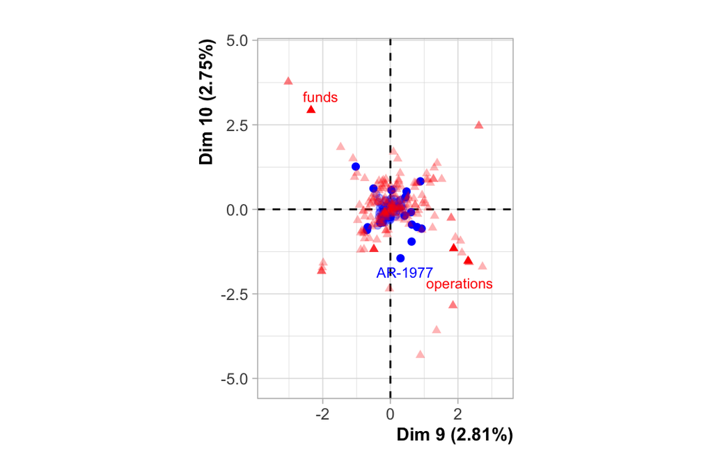

**Figure 7.1 - Overlayed factor map (CA)** *The labeled rows are those with the higher contribution to the plane construction.* *The labeled columns are those the best shown on the plane.*

The **dimension 9** opposes factors such as *AR-1966*, *AR-1967*, *AR-1965*, *AR-1977*, *AR-2002*, *AR-1968* and *AR-1970* (to the right of the graph, characterized by a strongly positive coordinate on the axis) to factors such as *AR-1934*, *AR-1935*, *AR-1919* and *AR-1918* (to the left of the graph, characterized by a strongly negative coordinate on the axis).

The group in which the factors *AR-1966*, *AR-1967*, *AR-1965*, *AR-1977*, *AR-2002*, *AR-1968* and *AR-1970* stand (characterized by a positive coordinate on the axis) is sharing :

- high frequency for factors like *fellowship*, *students*, *operations*, *support*, *agricultural*, *faculty*, *program*, *policy*, *contribution* and *theatre* (factors are sorted from the most common).
- low frequency for factors like *health*, *public*, *division*, *medical*, *aid*, *council*, *studies*, *ih*, *medicine* and *american* (factors are sorted from the rarest).

The group in which the factors *AR-1934*, *AR-1935*, *AR-1919* and *AR-1918* stand (characterized by a negative coordinate on the axis) is sharing :

- high frequency for factors like *council*, *social*, *aid*, *grants*, *foundation*, *studies*, *american*, *division*, *public* and *fellowships* (factors are sorted from the most common).
- low frequency for factors like *center*, *agricultural*, *faculty*, *support*, *project*, *costs*, *development*, *arts*, *fellowship* and *usa* (factors are sorted from the rarest).

The **dimension 10** opposes factors such as *AR-1994*, *AR-1928*, *AR-1926*, *AR-1992* and *AR-1925* (to the top of the graph, characterized by a strongly positive coordinate on the axis) to factors such as *AR-1966*, *AR-1967*, *AR-1965*, *AR-1977*, *AR-1934*, *AR-1935*, *AR-1919*, *AR-2002*, *AR-1968* and *AR-1918* (to the bottom of the graph, characterized by a strongly negative coordinate on the axis).

The group in which the factors *AR-1994*, *AR-1928*, *AR-1926*, *AR-1992* and *AR-1925* stand (characterized by a positive coordinate on the axis) is sharing :

- high frequency for factors like *nursing*, *developing*, *rice*, *hygiene*, *service*, *arts*, *america*, *japan*, *african* and *plant* (factors are sorted from the most common).
- low frequency for the factors *grants*, *social*, *council*, *foundation* and *aid* (factors are sorted from the rarest).

The group in which the factors *AR-1966*, *AR-1967*, *AR-1965*, *AR-1977*, *AR-2002*, *AR-1968* and *AR-1970* stand (characterized by a negative coordinate on the axis) is sharing :

- high frequency for factors like *fellowship*, *students*, *operations*, *support*, *agricultural*, *faculty*, *program*, *policy*, *contribution* and *theatre* (factors are sorted from the most common).
- low frequency for factors like *health*, *public*, *division*, *medical*, *aid*, *council*, *studies*, *ih*, *medicine* and *american* (factors are sorted from the rarest).

The group in which the factors *AR-1934*, *AR-1935*, *AR-1919* and *AR-1918* stand (characterized by a negative coordinate on the axis) is sharing :

- high frequency for factors like *council*, *social*, *aid*, *grants*, *foundation*, *studies*, *american*, *division*, *public* and *fellowships* (factors are sorted from the most common).
- low frequency for factors like *center*, *agricultural*, *faculty*, *support*, *project*, *costs*, *development*, *arts*, *fellowship* and *usa* (factors are sorted from the rarest).

### 8. Description of the plane 11:12

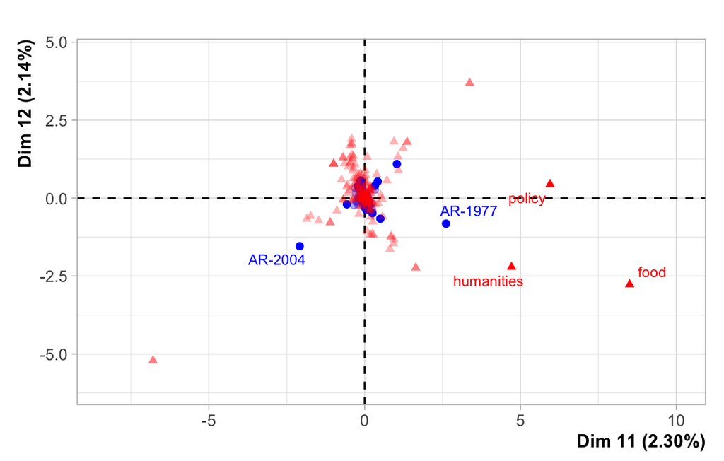

**Figure 8.1 - Overlayed factor map (CA)** *The labeled rows are those with the higher contribution to the plane construction.* *The labeled columns are those the best shown on the plane.*

The **dimension 11** opposes factors such as *AR-1977* (to the right of the graph, characterized by a strongly positive coordinate on the axis) to factors such as *AR-2004* (to the left of the graph, characterized by a strongly negative coordinate on the axis).

The group in which the factor *AR-1977* stands (characterized by a positive coordinate on the axis) is sharing :

- high frequency for the factors *food*, *humanities* and *policy* (factors are sorted from the most common).

The group in which the factor *AR-2004* stands (characterized by a negative coordinate on the axis) is sharing :

- high frequency for the factors *communities*, *regional*, *global*, *africa*, *project* and *costs* (factors are sorted from the most common).

The **dimension 12** opposes factors such as *AR-2002*, *AR-1963*, *AR-1962*, *AR-1961*, *AR-1933*, *AR-1935*, *AR-1992*, *AR-1930* and *AR-1994* (to the top of the graph, characterized by a strongly positive coordinate on the axis) to factors such as *AR-1977*, *AR-2004*, *AR-1951*, *AR-1950*, *AR-1928*, *AR-1953*, *AR-1952* and *AR-1999* (to the bottom of the graph, characterized by a strongly negative coordinate on the axis).

The group in which the factors *AR-2002*, *AR-1963*, *AR-1962*, *AR-1961*, *AR-1933*, *AR-1935*, *AR-1992*, *AR-1930* and *AR-1994* stand (characterized by a positive coordinate on the axis) is sharing :

- high frequency for factors like *sciences*, *city*, *science*, *ih*, *fellowships*, *gold*, *fever*, *yellow*, *school* and *aid* (factors are sorted from the most common).

The group in which the factor *AR-2004* stands (characterized by a negative coordinate on the axis) is sharing :

- high frequency for the factors *communities*, *regional*, *global*, *africa*, *project* and *costs* (factors are sorted from the most common).

The group in which the factors *AR-1951*, *AR-1950*, *AR-1928*, *AR-1953*, *AR-1952* and *AR-1999* stand (characterized by a negative coordinate on the axis) is sharing :

- high frequency for the factors *economic*, *chemistry*, *history*, *england* and *equipment* (factors are sorted from the most common).
- low frequency for factors like *city*, *sciences*, *science*, *gold*, *yellow*, *ih*, *fever*, *fellowships*, *washington* and *countries* (factors are sorted from the rarest).

The group in which the factor *AR-1977* stands (characterized by a negative coordinate on the axis) is sharing :

- high frequency for the factors *food*, *humanities* and *policy* (factors are sorted from the most common).

### 9. Classification

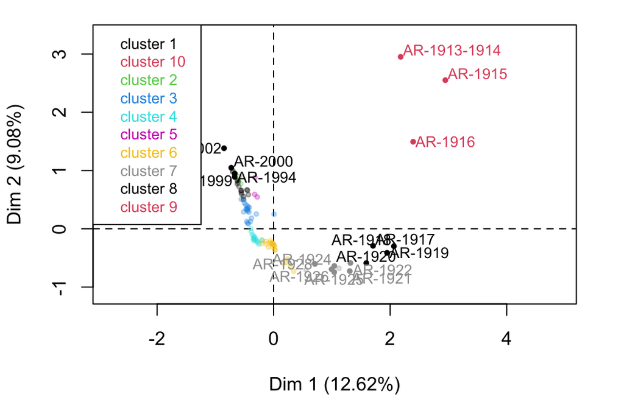

**Figure 9 - Ascending Hierachical Classification of the rows.** *The classification made on rows reveals 10 clusters.*

The cluster 1 is made of rows such as *AR-2002*, *AR-2000*, *AR-1994* and *AR-1999*. This group is characterized by :

- high frequency for factors like *support*, *rice*, *project*, *kenya*, *global*, *development*, *costs*, *center*, *california* and *arts* (factors are sorted from the most common).
- low frequency for factors like *college*, *ih*, *medical*, *school*, *social*, *studies*, *department*, *american*, *medicine* and *aid* (factors are sorted from the rarest).

The cluster 2 is made of rows sharing :

- high frequency for the factors *united*, *support*, *climate*, *change*, *costs*, *development* and *health* (factors are sorted from the most common).
- low frequency for factors like *university*, *program*, *study*, *institute*, *international*, *medical*, *school*, *public*, *sciences* and *studies* (factors are sorted from the rarest).

The cluster 3 is made of rows sharing :

- high frequency for factors like *university*, *program*, *fellowship*, *development*, *center*, *students*, *operations*, *international*, *support* and *agricultural* (factors are sorted from the most common).
- low frequency for factors like *health*, *ih*, *medical*, *public*, *medicine*, *aid*, *division*, *china*, *board* and *hookworm* (factors are sorted from the rarest).

The cluster 4 is made of rows sharing :

- high frequency for factors like *visit*, *usa*, *travel*, *study*, *science*, *professor*, *plant*, *mexico*, *medicine* and *japan* (factors are sorted from the most common).
- low frequency for factors like *board*, *china*, *control*, *costs*, *health*, *hookworm*, *ih*, *malaria*, *project* and *disease* (factors are sorted from the rarest).

The cluster 5 is made of rows sharing :

- high frequency for factors like *special*, *corporation*, *company*, *institutional*, *environmental*, *university*, *continued*, *grant*, *population* and *program* (factors are sorted from the most common).
- low frequency for factors like *health*, *medical*, *support*, *studies*, *social*, *ih*, *costs*, *department*, *medicine* and *aid* (factors are sorted from the rarest).

The cluster 6 is made of rows sharing :

- high frequency for factors like *studies*, *social*, *public*, *ih*, *health*, *fellowships*, *division*, *council*, *city* and *american* (factors are sorted from the most common).
- low frequency for factors like *agricultural*, *agriculture*, *board*, *center*, *costs*, *faculty*, *project*, *support*, *usa* and *disease* (factors are sorted from the rarest).

The cluster 7 is made of rows such as *AR-1928*, *AR-1926*, *AR-1925*, *AR-1924*, *AR-1921* and *AR-1922*. This group is characterized by :

- high frequency for factors like *service*, *medical*, *malaria*, *journal*, *ih*, *hygiene*, *hospital*, *hookworm*, *health* and *county* (factors are sorted from the most common).
- low frequency for factors like *development*, *institute*, *program*, *sciences*, *study*, *support*, *university*, *foundation*, *social* and *center* (factors are sorted from the rarest).

The cluster 8 is made of rows such as *AR-1920*, *AR-1917*, *AR-1919* and *AR-1918*. This group is characterized by :

- high frequency for factors like *treatment*, *medical*, *measures*, *latrine*, *infection*, *hospital*, *hookworm*, *exhibit*, *disease* and *control* (factors are sorted from the most common).
- low frequency for factors like *university*, *program*, *study*, *institute*, *development*, *support*, *sciences*, *studies*, *united* and *national* (factors are sorted from the rarest).

The cluster 9 is made of rows such as *AR-1913-1914*. This group is characterized by :

- high frequency for factors like *corporation*, *commission*, *time*, *income*, *john*, *meeting*, *society*, *company*, *relief* and *committee* (factors are sorted from the most common).
- low frequency for factors like *university*, *program*, *study*, *institute*, *development*, *school*, *public*, *support*, *sciences* and *studies* (factors are sorted from the rarest).

The cluster 10 is made of rows such as *AR-1916* and *AR-1915*. This group is characterized by :

- high frequency for factors like *treatment*, *relief*, *persons*, *infected*, *examined*, *december*, *cured*, *commission*, *total* and *sanitary* (factors are sorted from the most common).
- low frequency for factors like *university*, *program*, *study*, *institute*, *development*, *support*, *sciences*, *studies*, *united* and *national* (factors are sorted from the rarest).

## Annexes

```r
res.hcpc$desc.var
```

```
$`1`
                 Intern %      glob % Intern freq Glob freq        p.value
support         7.6209071  2.16812875        4918      10536  0.000000e+00
rice            1.4736646  0.19569955         951        951  0.000000e+00
project         5.0625261  0.71591875        3267       3479  0.000000e+00
kenya           1.1265554  0.14960418         727        727  0.000000e+00
global          0.7515535  0.09980471         485        485  0.000000e+00
development     6.0635644  2.54738666        3913      12379  0.000000e+00
costs           8.0238018  1.20465316        5178       5854  0.000000e+00
center          3.7035315  1.33676579        2390       6496  0.000000e+00
california      1.2009360  0.15948176         775        775  0.000000e+00
arts            1.2458742  0.18808558         804        914  0.000000e+00
african         0.8708723  0.11565000         562        562  0.000000e+00
africa          1.6425705  0.23994287        1060       1166  0.000000e+00
population      1.2505230  0.30620497         807       1488 1.314736e-307
developing      0.6802721  0.11174012         439        543 1.824037e-278
funds           0.3672540  0.04877055         237        237 2.157232e-208
washington      0.4819240  0.08601726         311        418 4.698854e-178
program         5.5305038  3.62918743        3569      17636 2.560875e-150
addition        0.1998977  0.02654600         129        129 1.394668e-113
international   4.8192398  3.27071359        3110      15894 8.886488e-112
prior           0.1844018  0.02448817         119        119 8.313322e-105
communities     0.1828522  0.02428238         118        118 6.270076e-104
joint           0.1720050  0.02284190         111        111  8.701549e-98
conference      0.1642570  0.02181299         106        106  2.122244e-93
held            0.1627075  0.02160721         105        105  1.600359e-92
activities      0.1596083  0.02119564         103        103  9.100060e-91
regional        0.1580587  0.02098986         102        102  6.861972e-90
total           0.3595060  0.13437624         232        653  8.397301e-47
policy          0.1658066  0.04424333         107        215  2.010847e-37
enable          0.1596083  0.04218550         103        205  1.520367e-36
community       0.1627075  0.04403754         105        214  4.822462e-36
university     11.8048130 10.58176887        7618      51422  1.101516e-26
united          2.2887515  1.77487761        1477       8625  1.504077e-24
institute       4.1668604  3.50612924        2689      17038  1.191799e-21
health          6.0372213  5.29273648        3896      25720  5.395872e-19
countries       0.1580587  0.09054448         102        440  2.309206e-08
agricultural    1.0304805  0.84288680         665       4096  5.891304e-08
foundation      9.2603784  9.55594106        5976      46437  6.056195e-03
viruses         0.0000000  0.02098986           0        102  9.740884e-07
```

[output cut: 2602 more lines]

```
college         0.000000  1.40693777           0       6837  6.495241e-60 -16.325550
american        0.000000  1.49789381           0       7279  8.655936e-64 -16.861370
national        0.000000  1.61107441           0       7829  1.288489e-68 -17.506041
united          0.000000  1.77487761           0       8625  1.299614e-75 -18.400582
studies         0.000000  2.00144460           0       9726  2.614376e-85 -19.573255
sciences        0.000000  2.00247351           0       9731  2.362009e-85 -19.578427
support         0.000000  2.16812875           0      10536  1.858969e-92 -20.394820
development     0.000000  2.54738666           0      12379 9.103250e-109 -22.156137
institute       0.000000  3.50612924           0      17038 2.757852e-150 -26.110677
study           0.000000  3.59194072           0      17455 5.060338e-154 -26.437650
program         0.000000  3.62918743           0      17636 1.205987e-155 -26.578416
university      0.000000 10.58176887           0      51422  0.000000e+00       -Inf

attr(,"class")
[1] "descfreq" "list"
```

**Figure 10 - List of variables characterizing the clusters of the classification.**